# Metod beskrivning

Offerter i portföljen kan anses som *ett system av linjära ekvationer* där ingående material kan betraktas som komponentmängder (mängder måste då vara kända eller antagdna vid upphandlingen): $A_1, A_2, A_3 ...A_n$ och deras motsvarande priser (som är från början okända): $x_1, x_2 , x_3 ...x_n$ där totalpriset (det enda pris som är angivet från början i offert) $P$ är resultatet.

För att komma fram till underligande komoponent priser $x_1, x_2 , x_3$ måste eqvationer sammanfattas i ett system av linjära ekvationer

$$A_1x_1 + A_2x_2 + A_3x_3 = P_1$$$$A_1x_1 + A_2x_2 + A_3x_3 = P_2$$$$A_1x_1 + A_2x_2 + A_3x_3 = P_3$$

dessa kan sen beskrivas i följande ekvation:

# $$Ax=P$$

där $Ax$ och $P$ sammanfattas i matris form enligt följande:

$$ Ax = \begin{bmatrix} A_1{⋅}x_1 & A_2{⋅}x_2 & A_3{⋅}x_3 &\cdots \\ A_1{⋅}x_1 & A_2{⋅}x_2 & A_3{⋅}x_3 &\cdots\\ A_1{⋅}x_1 & A_2{⋅}x_2 & A_3{⋅}x_3 &\cdots\\\vdots & \vdots & \vdots \\ \end{bmatrix} \text{och}\ P = \begin{bmatrix} P_1 \\P_2 \\ P_3\\\ \vdots \\ \end{bmatrix}$$

${Ax}$ kan sen delas vidare i två vektorer motsvarande:

$$ A = \begin{bmatrix} A_1 & A_2 & A_3 \\ A_1 & A_2 & A_3 \\ A_1 & A_2 & A_3 \end{bmatrix}$$

\

$$ x = \begin{bmatrix} x_1 \\ x_2 \\ x_3 \end{bmatrix}$$

Enligt matriser ovan, kan $x_1, x_2 , x_3$ bestämmas genom att lösa ekvations system

$$ x_1 \begin{bmatrix} A_1 \\ A_2 \\ A_3 \end{bmatrix} + x_2 \begin{bmatrix} A_1 \\ A_2 \\ A_3 \end{bmatrix} + x_3 \begin{bmatrix} A_1 \\ A_2 \\ A_3 \end{bmatrix} = \begin{bmatrix} P_1 \\P_2 \\ P_3 \\ \end{bmatrix}$$

\

Genoma att lösa $Ax=P$ kommer man då till komoponent priser $x_1, x_2 , x_3$ i portföljen:

\ $$x_1 = \text{elementpris}_1 $$

$$x_2 = \text{elementpris}_2$$$$x_3 = \text{elementpris}_3$$

# Exempel 1

Offert som visar produkt bestående av 3 olika ingående delar och som visar enbart totalpriset per produkt (priser av ingpende delar framgår inte)

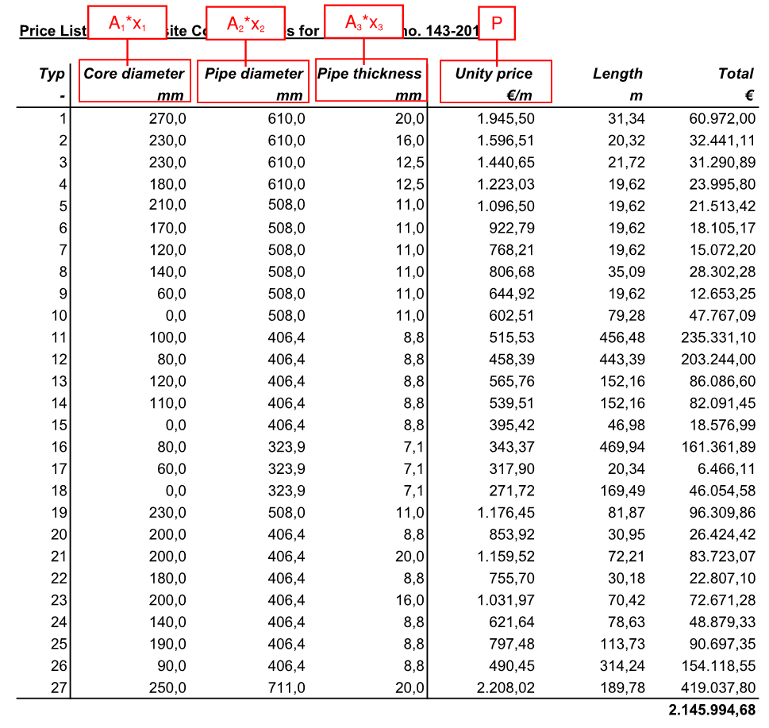

Genoma att lösa $Ax=P$ kommer man då till följande komoponent priser som sen omvandlade till totalpriset visar skillnad mot det offererade priset

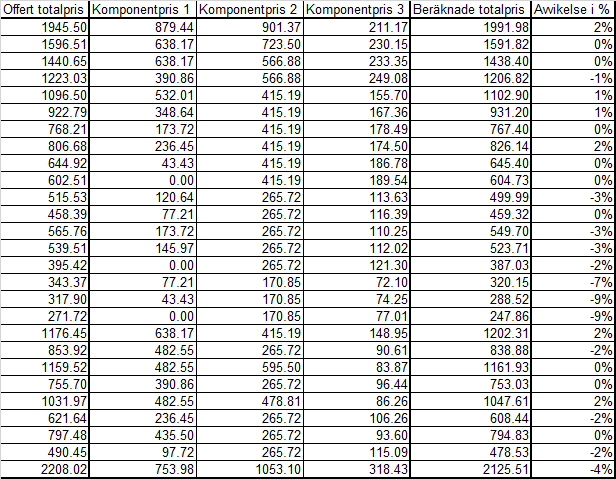

# Exempel 2

obs: detta är ett exempel med väldigt grova ingångsvärden, som ger större spridning i resultatet

Entreprenadpris av några betong sändwich projekt, där vid lösning av $Ax=P$ två nedersta, rödmarkerade priser var inte med i beräkningen och då beräknade kalkylpriser är framtagna matematiskt utan att ha med ingångsvärden i beräkningsmodell - alltså rent prognospris, som ändå kommer nära med tanke på litet antal ingångsvärden.

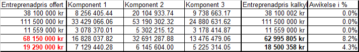

# Exempel 3

Exempel med bra underlag till ingångsvärden av stål och betong totalenterprenad. Fördelen med denna metod visas tydligt då inte bara prognoserade preiser är inom väldigt liten marginal, utan även ge prognos till en hela enterprenad inte bara viss material typ - detta är möjligt just tack vare linjära relationen av ingående värden, alltså alla förändringar speglas i prisen då ändring av en viss komponen linjärt ändrar kostnader totalt.

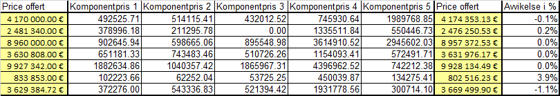